# Spatial-Copy4

[figure not shown]

The legacy of apartheid in South Africa continues to disrupt society today. Apartheid is the former policy of economic and political discrimination, and segregation against non-european groups in South Africa. One such example is that of spatial apartheid, where residential areas were segregated based on race. The remnants of such policies are still visible today and moving around residential areas shows many completely segregated neighbourhoods of townships next to gated wealthy neighbourhoods that have largely remained unaffected by the ending of apartheid. Our research proposes the use of computer vision to analyse satellite images of South Africa from 2006 to 2016. This work aims to understand the relationship between the spatial and socioeconomic makeup of neighbourhoods in South Africa, and also studies how they have evolved over time in post Apartheid. To accomplish this we will be using satellite images, geographically and semantically labelled coordinates of all the buildings in South Africa and socioeconomic data to build a semantic segmentation model that can predict a geographical neighbourhood class as township, suburb, informal settlement, etc. In addition to automatically detecting and classifying neighbourhoods, we plan to use demographic and socioeconomic data to analyze the change over time in the demographic makeup, economic status and access to basic resources such as the number of clinics and schools of these detected neighbourhoods.

## 2013 Shapefile Data

### Number of datapoints

7 752 648 rows x 9 columns

```python
shp_13.head()
```

|  | objectid | class_name | base_year | province | municipali | source_img | y_coord | x_coord | geometry |
| --- | --- | --- | --- | --- | --- | --- | --- | --- | --- |
| 0 | 922.0 | Dwelling | 2013.0 | Western Cape | City of Cape Town Metropolitan Municipality | SPOT5 2013 | -34.005466 | 18.618589 | POINT (18.61858966099999 -34.00546797700002) |
| 1 | 923.0 | Dwelling | 2013.0 | Western Cape | City of Cape Town Metropolitan Municipality | SPOT5 2013 | -34.002964 | 18.619370 | POINT (18.61937012499999 -34.00296478400003) |
| 2 | 924.0 | Dwelling | 2013.0 | Western Cape | City of Cape Town Metropolitan Municipality | SPOT5 2013 | -34.002792 | 18.618303 | POINT (18.618304126 -34.00279346299999) |
| 3 | 661.0 | Dwelling | 2013.0 | North West | Greater Taung | SPOT5 2013 | -27.591721 | 24.867279 | POINT (24.86727881399997 -27.59172033099998) |
| 4 | 662.0 | Dwelling | 2013.0 | North West | Greater Taung | SPOT5 2013 | -27.593962 | 24.868315 | POINT (24.86831387900003 -27.59396178399999) |

### Attributes in dataset

```python
print(shp_13.columns.unique())
```

```
Index([  u'objectid', u'class_name',  u'base_year',   u'province',
       u'municipali', u'source_img',    u'y_coord',    u'x_coord',
         u'geometry'],
      dtype='object')
```

### Provinces in dataset

```python
shp_13['province'].unique()
```

```
array([u'Western Cape', 'North West', u'Northern Cape', u'Limpopo',
       u'Mpumalanga', u'Gauteng', u'Free State', u'KwaZulu-Natal',
       u'Eastern Cape'], dtype=object)
```

### Class names in dataset

```python
shp_13['class_name'].unique()
```

```
array([u'Dwelling', u'Resort', u'Reservoir', u'Commercial',
       u'Dense Informal', u'Complex/Hostel', u'Mine/Quarry',
       u'Place of worship', u'Other built-up', u'Industrial',
       u'Agricultural Supplies', u'other-built-up', u'Airport',
       u'Reservoirs', u'School', u'Agricultural supplies',
       u'Agricultural supplie', u'dwelling', u'Game Reserve',
       u'Education Facility', u'Correctional Facility',
       u'Health Facility', u'Tetiary Institution', u'Other Built-up',
       u'Recreational', u'Police Station', u'Lodge', u'Train Station',
       u'Public Library', u'College', u'Fire Station', u'Power Station',
       u'Correctional Service', u'Substation', u'Agricultural Supply',
       u'Historic Site', u'GardenCentre/Nursery', u'University', u'Hotel',
       u'Post Office', u'Nature Reserve', u'Industrial/Commerci*',
       u'Sport Facility', u'Agriculture', u'Farm', u'Non Existing',
       u'Government Building', u'Under Construction'], dtype=object)
```

### Plot of dwellings per province

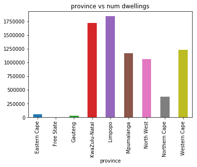

```python
shp_13.groupby(['class_name']).get_group('Dwelling').groupby(['province']).size().plot.bar(title="province vs num dwellings")
```

### Number of dwellings per province

```python
shp_13.groupby(['class_name']).get_group('Dwelling').groupby(['province']).size()
```

```
province
Eastern Cape       55470
Free State          4861
Gauteng            27605
KwaZulu-Natal    1725192
Limpopo          1843192
Mpumalanga       1166464
North West       1062943
Northern Cape     374753
Western Cape     1229820
dtype: int64
```

### Plotting the data

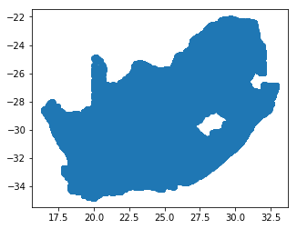

```python
shp_13.plot()
```

#### Gauteng plot

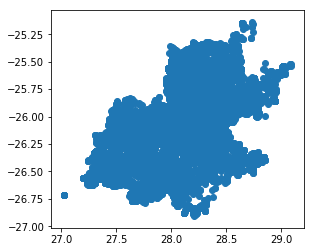

```python
shp_13.groupby(['province']).get_group('Gauteng').plot()
```

```python
subplace = gpd.GeoDataFrame.from_file('stats_sa_data/SP_SA_2011_Apr2013.shp')
```

```python
subplace.tail()
```

|  | SP_CODE | SP_NAME | MP_CODE | MP_NAME | MN_MDB_C | MN_CODE | MN_NAME | DC_MDB_C | DC_MN_C | DC_NAME | PR_MDB_C | PR_CODE | PR_NAME | ALBERS_ARE | Shape_Leng | Shape_Area | geometry |
| --- | --- | --- | --- | --- | --- | --- | --- | --- | --- | --- | --- | --- | --- | --- | --- | --- | --- |
| 22103 | 987147001.0 | Tukakgomo SP | 987147.0 | Tukakgomo | LIM475 | 987.0 | Greater Tubatse | DC47 | 947.0 | Greater Sekhukhune | LIM | 9.0 | Limpopo | 10.158532 | 0.210826 | 0.000907 | POLYGON ((30.13271616300005 -24.72552828899995... |
| 22104 | 987148001.0 | Stocking SP | 987148.0 | Stocking | LIM475 | 987.0 | Greater Tubatse | DC47 | 947.0 | Greater Sekhukhune | LIM | 9.0 | Limpopo | 3.486518 | 0.083287 | 0.000311 | POLYGON ((30.11605522900004 -24.71469763099998... |
| 22105 | 987149001.0 | Ga-Phasha SP | 987149.0 | Ga-Phasha | LIM475 | 987.0 | Greater Tubatse | DC47 | 947.0 | Greater Sekhukhune | LIM | 9.0 | Limpopo | 3.136779 | 0.140385 | 0.000280 | POLYGON ((30.12583752400008 -24.75671370999993... |
| 22106 | 987150001.0 | Motate SP | 987150.0 | Motate | LIM475 | 987.0 | Greater Tubatse | DC47 | 947.0 | Greater Sekhukhune | LIM | 9.0 | Limpopo | 1.868240 | 0.095706 | 0.000167 | POLYGON ((30.10941929200004 -24.77128310099994... |
| 22107 | 987151001.0 | Ga-Mampuru SP | 987151.0 | Ga-Mampuru | LIM475 | 987.0 | Greater Tubatse | DC47 | 947.0 | Greater Sekhukhune | LIM | 9.0 | Limpopo | 6.969835 | 0.217277 | 0.000622 | POLYGON ((30.10464404500004 -24.78774515499998... |

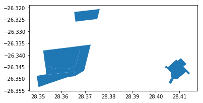

```python
subplace[subplace['PR_NAME']=='Gauteng'].head().plot()
```

```python
subplace.columns.unique()
```

```
Index([   u'SP_CODE',    u'SP_NAME',    u'MP_CODE',    u'MP_NAME',
         u'MN_MDB_C',    u'MN_CODE',    u'MN_NAME',   u'DC_MDB_C',
          u'DC_MN_C',    u'DC_NAME',   u'PR_MDB_C',    u'PR_CODE',
          u'PR_NAME', u'ALBERS_ARE', u'Shape_Leng', u'Shape_Area',
         u'geometry'],
      dtype='object')
```

```python
subplace.PR_NAME.unique()
```

```
array([u'Western Cape', u'Eastern Cape', u'Northern Cape', u'Free State',
       u'KwaZulu-Natal', u'North West', u'Gauteng', u'Mpumalanga',
       u'Limpopo'], dtype=object)
```

```python
subplace[subplace['PR_NAME']=='Gauteng']
```

|  | SP_CODE | SP_NAME | MP_CODE | MP_NAME | MN_MDB_C | MN_CODE | MN_NAME | DC_MDB_C | DC_MN_C | DC_NAME | PR_MDB_C | PR_CODE | PR_NAME | ALBERS_ARE | Shape_Leng | Shape_Area | geometry |
| --- | --- | --- | --- | --- | --- | --- | --- | --- | --- | --- | --- | --- | --- | --- | --- | --- | --- |
| 15183 | 797024009.0 | Langaville Ext 8 | 797024.0 | Langaville | EKU | 797.0 | Ekurhuleni | EKU | 797.0 | Ekurhuleni | GT | 7.0 | Gauteng | 0.550608 | 0.039184 | 0.000050 | POLYGON ((28.41059327000005 -26.34133974199995... |
| 15184 | 797025001.0 | Geluksdal Ext 3 | 797025.0 | Geluksdal | EKU | 797.0 | Ekurhuleni | EKU | 797.0 | Ekurhuleni | GT | 7.0 | Gauteng | 0.455735 | 0.028681 | 0.000041 | POLYGON ((28.36721131200005 -26.32571984299994... |
| 15185 | 797025002.0 | Geluksdal SP | 797025.0 | Geluksdal | EKU | 797.0 | Ekurhuleni | EKU | 797.0 | Ekurhuleni | GT | 7.0 | Gauteng | 1.309695 | 0.044978 | 0.000118 | POLYGON ((28.36591128200007 -26.34440665899996... |
| 15186 | 797025003.0 | Geluksdal Ext 1 | 797025.0 | Geluksdal | EKU | 797.0 | Ekurhuleni | EKU | 797.0 | Ekurhuleni | GT | 7.0 | Gauteng | 0.835237 | 0.060952 | 0.000076 | POLYGON ((28.36984873700004 -26.34574072799995... |
| 15187 | 797025004.0 | Geluksdal Ext 2 | 797025.0 | Geluksdal | EKU | 797.0 | Ekurhuleni | EKU | 797.0 | Ekurhuleni | GT | 7.0 | Gauteng | 0.554754 | 0.039117 | 0.000050 | POLYGON ((28.36549726600003 -26.34744367999997... |
| 15188 | 797026001.0 | Tsakane Ext 1 | 797026.0 | Tsakane | EKU | 797.0 | Ekurhuleni | EKU | 797.0 | Ekurhuleni | GT | 7.0 | Gauteng | 1.249919 | 0.053681 | 0.000113 | POLYGON ((28.38410448900004 -26.34053734399998... |
| 15189 | 797026002.0 | Tsakane SP | 797026.0 | Tsakane | EKU | 797.0 | Ekurhuleni | EKU | 797.0 | Ekurhuleni | GT | 7.0 | Gauteng | 6.346506 | 0.135083 | 0.000574 | POLYGON ((28.38401233400003 -26.33767912399998... |
| 15190 | 797026003.0 | Tsakane Ext 5 | 797026.0 | Tsakane | EKU | 797.0 | Ekurhuleni | EKU | 797.0 | Ekurhuleni | GT | 7.0 | Gauteng | 1.467637 | 0.053085 | 0.000133 | POLYGON ((28.36842221600006 -26.35188735799994... |
| 15191 | 797026004.0 | Tsakane Ext 11 | 797026.0 | Tsakane | EKU | 797.0 | Ekurhuleni | EKU | 797.0 | Ekurhuleni | GT | 7.0 | Gauteng | 1.407847 | 0.047870 | 0.000127 | POLYGON ((28.35837686300005 -26.35163866499994... |
| 15192 | 797026005.0 | Tsakane Ext 8 | 797026.0 | Tsakane | EKU | 797.0 | Ekurhuleni | EKU | 797.0 | Ekurhuleni | GT | 7.0 | Gauteng | 2.206360 | 0.064356 | 0.000200 | POLYGON ((28.36518970800006 -26.36495136099995... |
| 15193 | 797026006.0 | Tsakane Ext 12 | 797026.0 | Tsakane | EKU | 797.0 | Ekurhuleni | EKU | 797.0 | Ekurhuleni | GT | 7.0 | Gauteng | 0.606145 | 0.045251 | 0.000055 | POLYGON ((28.36988541700003 -26.35644133699998... |
| 15194 | 797026007.0 | Tsakane Ext 9 | 797026.0 | Tsakane | EKU | 797.0 | Ekurhuleni | EKU | 797.0 | Ekurhuleni | GT | 7.0 | Gauteng | 1.772266 | 0.074735 | 0.000160 | POLYGON ((28.37728222700002 -26.37771380899994... |
| 15195 | 797026008.0 | Tsakane Ext 15 | 797026.0 | Tsakane | EKU | 797.0 | Ekurhuleni | EKU | 797.0 | Ekurhuleni | GT | 7.0 | Gauteng | 0.885597 | 0.044952 | 0.000080 | POLYGON ((28.38769031300006 -26.37869933299993... |
| 15196 | 797026009.0 | Tsakane Ext 13 | 797026.0 | Tsakane | EKU | 797.0 | Ekurhuleni | EKU | 797.0 | Ekurhuleni | GT | 7.0 | Gauteng | 0.170708 | 0.021082 | 0.000015 | POLYGON ((28.38168840600002 -26.36547904499997... |
| 15197 | 797026010.0 | Tsakane Ext 16 | 797026.0 | Tsakane | EKU | 797.0 | Ekurhuleni | EKU | 797.0 | Ekurhuleni | GT | 7.0 | Gauteng | 0.917737 | 0.043981 | 0.000083 | POLYGON ((28.38827144700008 -26.37819856799996... |
| 15198 | 797026011.0 | Tsakane Ext 17 | 797026.0 | Tsakane | EKU | 797.0 | Ekurhuleni | EKU | 797.0 | Ekurhuleni | GT | 7.0 | Gauteng | 1.270682 | 0.045003 | 0.000115 | POLYGON ((28.39282870800002 -26.36175810199995... |
| 15199 | 797026012.0 | Tsakane Ext 19 | 797026.0 | Tsakane | EKU | 797.0 | Ekurhuleni | EKU | 797.0 | Ekurhuleni | GT | 7.0 | Gauteng | 1.453190 | 0.057155 | 0.000131 | POLYGON ((28.40603138500006 -26.36117427199997... |
| 15200 | 797027001.0 | Duduza SP | 797027.0 | Duduza | EKU | 797.0 | Ekurhuleni | EKU | 797.0 | Ekurhuleni | GT | 7.0 | Gauteng | 4.188172 | 0.093368 | 0.000379 | POLYGON ((28.41816180500007 -26.37590899799994... |
| 15201 | 797027002.0 | Bluegum View | 797027.0 | Duduza | EKU | 797.0 | Ekurhuleni | EKU | 797.0 | Ekurhuleni | GT | 7.0 | Gauteng | 4.018588 | 0.139907 | 0.000363 | POLYGON ((28.39439691200005 -26.37566882399994... |
| 15202 | 798026012.0 | Meadowlands West Zone 8 | 798026.0 | Soweto | JHB | 798.0 | City of Johannesburg | JHB | 798.0 | City of Johannesburg | GT | 7.0 | Gauteng | 0.430681 | 0.027378 | 0.000039 | POLYGON ((27.88396493500005 -26.20339812499998... |
| 15203 | 798026013.0 | Meadowlands West Zone 7 | 798026.0 | Soweto | JHB | 798.0 | City of Johannesburg | JHB | 798.0 | City of Johannesburg | GT | 7.0 | Gauteng | 0.688051 | 0.034366 | 0.000062 | POLYGON ((27.89462168800003 -26.21257853799995... |
| 15204 | 798026014.0 | Meadowlands East Zone 1 | 798026.0 | Soweto | JHB | 798.0 | City of Johannesburg | JHB | 798.0 | City of Johannesburg | GT | 7.0 | Gauteng | 1.393131 | 0.062440 | 0.000126 | POLYGON ((27.89957300000003 -26.20880399999993... |
| 15205 | 798026015.0 | Meadowlands East Zone 2 | 798026.0 | Soweto | JHB | 798.0 | City of Johannesburg | JHB | 798.0 | City of Johannesburg | GT | 7.0 | Gauteng | 0.681623 | 0.034389 | 0.000062 | POLYGON ((27.90028896100006 -26.21904356099998... |
| 15206 | 798026016.0 | Meadowlands West Zone 6 | 798026.0 | Soweto | JHB | 798.0 | City of Johannesburg | JHB | 798.0 | City of Johannesburg | GT | 7.0 | Gauteng | 0.739760 | 0.036836 | 0.000067 | POLYGON ((27.88651282300003 -26.21454121499994... |
| 15207 | 798026017.0 | Meadowlands West Zone 10 | 798026.0 | Soweto | JHB | 798.0 | City of Johannesburg | JHB | 798.0 | City of Johannesburg | GT | 7.0 | Gauteng | 1.050446 | 0.042892 | 0.000095 | POLYGON ((27.87571524800006 -26.21436181599995... |
| 15208 | 798026018.0 | Dobsonville | 798026.0 | Soweto | JHB | 798.0 | City of Johannesburg | JHB | 798.0 | City of Johannesburg | GT | 7.0 | Gauteng | 2.732560 | 0.071071 | 0.000247 | POLYGON ((27.87303255900002 -26.22619239499994... |
| 15209 | 798026019.0 | Bram Fischerville Ext 5 | 798026.0 | Soweto | JHB | 798.0 | City of Johannesburg | JHB | 798.0 | City of Johannesburg | GT | 7.0 | Gauteng | 0.800771 | 0.039475 | 0.000072 | POLYGON ((27.85749789200003 -26.20991416699997... |
| 15210 | 798026020.0 | Bram Fischerville Ext 3 | 798026.0 | Soweto | JHB | 798.0 | City of Johannesburg | JHB | 798.0 | City of Johannesburg | GT | 7.0 | Gauteng | 0.904611 | 0.048356 | 0.000082 | POLYGON ((27.85211259400006 -26.20054051499994... |
| 15211 | 798026021.0 | South Roodepoort Main Reef Areas Gold Mine | 798026.0 | Soweto | JHB | 798.0 | City of Johannesburg | JHB | 798.0 | City of Johannesburg | GT | 7.0 | Gauteng | 19.068516 | 0.308439 | 0.001722 | POLYGON ((27.84151231000004 -26.19292807599993... |
| 15212 | 798026022.0 | Bram Fischerville Ext 12 | 798026.0 | Soweto | JHB | 798.0 | City of Johannesburg | JHB | 798.0 | City of Johannesburg | GT | 7.0 | Gauteng | 3.556833 | 0.086627 | 0.000321 | POLYGON ((27.83205424900007 -26.18157808099994... |
| ... | ... | ... | ... | ... | ... | ... | ... | ... | ... | ... | ... | ... | ... | ... | ... | ... | ... |
| 18313 | 799069001.0 | Keinfontein SH | 799069.0 | Keinfontein | TSH | 799.0 | City of Tshwane | TSH | 799.0 | City of Tshwane | GT | 7.0 | Gauteng | 0.464220 | 0.031687 | 0.000042 | POLYGON ((28.49370755600006 -25.80275886199996... |
| 18314 | 799070001.0 | Rietfontein SH | 799070.0 | Rietfontein | TSH | 799.0 | City of Tshwane | TSH | 799.0 | City of Tshwane | GT | 7.0 | Gauteng | 15.240526 | 0.173316 | 0.001372 | POLYGON ((28.35374573400003 -25.84222753699993... |
| 18315 | 799071001.0 | Grootfontein Country Estates | 799071.0 | Grootfontein | TSH | 799.0 | City of Tshwane | TSH | 799.0 | City of Tshwane | GT | 7.0 | Gauteng | 3.784344 | 0.081869 | 0.000341 | POLYGON ((28.35667119100003 -25.87630976399993... |
| 18316 | 799072001.0 | Riamar park | 799072.0 | Bronkhorstspruit | TSH | 799.0 | City of Tshwane | TSH | 799.0 | City of Tshwane | GT | 7.0 | Gauteng | 3.972332 | 0.106369 | 0.000358 | POLYGON ((28.73494402100005 -25.80107559899994... |
| 18317 | 799072002.0 | Bronkhorstspruit SP | 799072.0 | Bronkhorstspruit | TSH | 799.0 | City of Tshwane | TSH | 799.0 | City of Tshwane | GT | 7.0 | Gauteng | 3.110531 | 0.081737 | 0.000280 | POLYGON ((28.75071937700005 -25.79686014299995... |
| 18318 | 799072003.0 | Masada | 799072.0 | Bronkhorstspruit | TSH | 799.0 | City of Tshwane | TSH | 799.0 | City of Tshwane | GT | 7.0 | Gauteng | 0.642520 | 0.034966 | 0.000058 | POLYGON ((28.75474422900004 -25.81396448999993... |
| 18319 | 799072004.0 | Caltura Park | 799072.0 | Bronkhorstspruit | TSH | 799.0 | City of Tshwane | TSH | 799.0 | City of Tshwane | GT | 7.0 | Gauteng | 1.907430 | 0.056108 | 0.000172 | POLYGON ((28.74675536900003 -25.82658055899998... |
| 18320 | 799072005.0 | Verster park SH | 799072.0 | Bronkhorstspruit | TSH | 799.0 | City of Tshwane | TSH | 799.0 | City of Tshwane | GT | 7.0 | Gauteng | 0.745265 | 0.035173 | 0.000067 | POLYGON ((28.72708854000007 -25.82421248999998... |
| 18321 | 799072006.0 | Kungwini Country Estate | 799072.0 | Bronkhorstspruit | TSH | 799.0 | City of Tshwane | TSH | 799.0 | City of Tshwane | GT | 7.0 | Gauteng | 7.325293 | 0.162000 | 0.000660 | POLYGON ((28.72153497600004 -25.88472539099996... |
| 18322 | 799072007.0 | Viljoenskop | 799072.0 | Bronkhorstspruit | TSH | 799.0 | City of Tshwane | TSH | 799.0 | City of Tshwane | GT | 7.0 | Gauteng | 8.262814 | 0.109152 | 0.000744 | POLYGON ((28.73252075000005 -25.90613409499997... |
| 18323 | 799072008.0 | Bronkhorstspruit Dam Nature Reserve | 799072.0 | Bronkhorstspruit | TSH | 799.0 | City of Tshwane | TSH | 799.0 | City of Tshwane | GT | 7.0 | Gauteng | 8.031344 | 0.190035 | 0.000724 | POLYGON ((28.69130952300003 -25.90031706099995... |
| 18324 | 799073001.0 | Bonamanzi Marina and Country Club SP | 799073.0 | Bonamanzi Marina and Country Club | TSH | 799.0 | City of Tshwane | TSH | 799.0 | City of Tshwane | GT | 7.0 | Gauteng | 3.088211 | 0.070534 | 0.000278 | POLYGON ((28.73579208400002 -25.90269355299995... |
| 18325 | 799074001.0 | Tweedracht AH | 799074.0 | Tweedracht | TSH | 799.0 | City of Tshwane | TSH | 799.0 | City of Tshwane | GT | 7.0 | Gauteng | 51.325886 | 0.299398 | 0.004623 | POLYGON ((28.52429161000003 -25.87609409099997... |
| 18326 | 799074002.0 | Tweefontein AH | 799074.0 | Tweedracht | TSH | 799.0 | City of Tshwane | TSH | 799.0 | City of Tshwane | GT | 7.0 | Gauteng | 16.360910 | 0.235005 | 0.001474 | POLYGON ((28.75344601000006 -25.91735815699997... |
| 18327 | 799075001.0 | Tierpoort SH | 799075.0 | Tierpoort | TSH | 799.0 | City of Tshwane | TSH | 799.0 | City of Tshwane | GT | 7.0 | Gauteng | 32.143407 | 0.220091 | 0.002895 | POLYGON ((28.43754810500008 -25.86062280399995... |
| 18328 | 799076001.0 | Bashewa SH | 799076.0 | Bashewa | TSH | 799.0 | City of Tshwane | TSH | 799.0 | City of Tshwane | GT | 7.0 | Gauteng | 13.201029 | 0.152517 | 0.001189 | POLYGON ((28.45544423700005 -25.92006364399998... |
| 18329 | 799077001.0 | Kameelkraal | 799077.0 | Kameelkraal | TSH | 799.0 | City of Tshwane | TSH | 799.0 | City of Tshwane | GT | 7.0 | Gauteng | 0.047077 | 0.008911 | 0.000004 | POLYGON ((28.53533286900006 -25.89902964099997... |
| 18330 | 799077002.0 | Kameelkraal SP | 799077.0 | Kameelkraal | TSH | 799.0 | City of Tshwane | TSH | 799.0 | City of Tshwane | GT | 7.0 | Gauteng | 0.051958 | 0.009839 | 0.000005 | POLYGON ((28.53269634600002 -25.90206578399994... |
| 18331 | 799078001.0 | Olievenhoutbos Ext 36 | 799078.0 | Olievenhoutbos | TSH | 799.0 | City of Tshwane | TSH | 799.0 | City of Tshwane | GT | 7.0 | Gauteng | 2.129333 | 0.056125 | 0.000192 | POLYGON ((28.10190754800004 -25.90530334999994... |
| 18332 | 799078002.0 | Olievenhoutbos | 799078.0 | Olievenhoutbos | TSH | 799.0 | City of Tshwane | TSH | 799.0 | City of Tshwane | GT | 7.0 | Gauteng | 0.925716 | 0.049124 | 0.000083 | POLYGON ((28.09581440600004 -25.90534224099997... |
| 18333 | 799078003.0 | Olievenhoutbos Ext 21 | 799078.0 | Olievenhoutbos | TSH | 799.0 | City of Tshwane | TSH | 799.0 | City of Tshwane | GT | 7.0 | Gauteng | 0.143416 | 0.015471 | 0.000013 | POLYGON ((28.09407706900004 -25.90826261099994... |
| 18334 | 799078004.0 | Olievenhoutbos Ext 15 | 799078.0 | Olievenhoutbos | TSH | 799.0 | City of Tshwane | TSH | 799.0 | City of Tshwane | GT | 7.0 | Gauteng | 0.590430 | 0.038927 | 0.000053 | POLYGON ((28.09690859400007 -25.90568632199995... |
| 18335 | 799078005.0 | Olievenhoutbos Ext 4, 19, 22 | 799078.0 | Olievenhoutbos | TSH | 799.0 | City of Tshwane | TSH | 799.0 | City of Tshwane | GT | 7.0 | Gauteng | 5.111315 | 0.115070 | 0.000460 | POLYGON ((28.12026786700005 -25.90028381299993... |
| 18336 | 799078006.0 | Olievenhoutbos Ext 24 | 799078.0 | Olievenhoutbos | TSH | 799.0 | City of Tshwane | TSH | 799.0 | City of Tshwane | GT | 7.0 | Gauteng | 0.414983 | 0.030855 | 0.000037 | POLYGON ((28.09834407300008 -25.91796601899995... |
| 18337 | 799078007.0 | Olievenhoutbos Ext 23 | 799078.0 | Olievenhoutbos | TSH | 799.0 | City of Tshwane | TSH | 799.0 | City of Tshwane | GT | 7.0 | Gauteng | 0.217519 | 0.023556 | 0.000020 | POLYGON ((28.09136116100007 -25.91578746499994... |
| 18338 | 799078008.0 | Olievenhoutbos Ext 13 | 799078.0 | Olievenhoutbos | TSH | 799.0 | City of Tshwane | TSH | 799.0 | City of Tshwane | GT | 7.0 | Gauteng | 0.402392 | 0.026749 | 0.000036 | POLYGON ((28.09729118200005 -25.90985379299997... |
| 18339 | 799078009.0 | Olievenhoutbos Ext 20 | 799078.0 | Olievenhoutbos | TSH | 799.0 | City of Tshwane | TSH | 799.0 | City of Tshwane | GT | 7.0 | Gauteng | 0.235333 | 0.018410 | 0.000021 | POLYGON ((28.09131846400004 -25.91520167499993... |
| 18340 | 799078010.0 | Olievenhoutbos Ext 26 | 799078.0 | Olievenhoutbos | TSH | 799.0 | City of Tshwane | TSH | 799.0 | City of Tshwane | GT | 7.0 | Gauteng | 1.026450 | 0.038232 | 0.000092 | POLYGON ((28.08749841200006 -25.91575760299997... |
| 18341 | 799078011.0 | Olievenhoutbos Ext 25 | 799078.0 | Olievenhoutbos | TSH | 799.0 | City of Tshwane | TSH | 799.0 | City of Tshwane | GT | 7.0 | Gauteng | 0.196326 | 0.018351 | 0.000018 | POLYGON ((28.09581645000003 -25.92361524899997... |
| 18342 | 799079001.0 | Blue Hills SH | 799079.0 | Blue Hills | TSH | 799.0 | City of Tshwane | TSH | 799.0 | City of Tshwane | GT | 7.0 | Gauteng | 0.262324 | 0.021909 | 0.000024 | POLYGON ((28.09132352600005 -25.92734279199993... |

2579 rows × 17 columns

```python
subplace.shape
```

```
(22108, 17)
```

```python
subplace[subplace['PR_NAME']=='Gauteng'].shape
```

```
(2579, 17)
```

## Image Clips

### Johannesburg 2015 (preprocessed satellite image)

[figure not shown]

### Some Johanessburg Townships encircled

[figure not shown]

### Johannesburg 2015: Zooming in President park(suburb:left) vs Tembisa(township:right)

[figure not shown]

### Johannesburg 2015: Zooming in President park vs Tembisa shapefiles overlayed)

[figure not shown]

### Sandton vs Industria vs Alex shapefiles overlayed on satellite image

[figure not shown]

### Sandton vs Industria vs Alex shapefiles overlayed on satellite image

[figure not shown]

### Alex township with subplace polygons

[figure not shown]

### Alex township with subplace polygons and house density

[figure not shown]